# Predicting fresh ratings on Rotten Tomatoes

```python
%matplotlib inline

import pandas as pd
import numpy as np
import matplotlib.pyplot as plt

pd.set_option('display.width', 500)
pd.set_option('display.max_columns', 30)

# set some nicer defaults for matplotlib
from matplotlib import rcParams

#these colors come from colorbrewer2.org. Each is an RGB triplet
dark2_colors = [(0.10588235294117647, 0.6196078431372549, 0.4666666666666667),
                (0.8509803921568627, 0.37254901960784315, 0.00784313725490196),
                (0.4588235294117647, 0.4392156862745098, 0.7019607843137254),
                (0.9058823529411765, 0.1607843137254902, 0.5411764705882353),
                (0.4, 0.6509803921568628, 0.11764705882352941),
                (0.9019607843137255, 0.6705882352941176, 0.00784313725490196),
                (0.6509803921568628, 0.4627450980392157, 0.11372549019607843),
                (0.4, 0.4, 0.4)]

rcParams['figure.figsize'] = (10, 6)
rcParams['figure.dpi'] = 150
rcParams['axes.color_cycle'] = dark2_colors
rcParams['lines.linewidth'] = 2
rcParams['axes.grid'] = False
rcParams['axes.facecolor'] = 'white'
rcParams['font.size'] = 14
rcParams['patch.edgecolor'] = 'none'
```

## Introduction

Rotten Tomatoes gathers movie reviews from critics. An [entry on the website](http://www.rottentomatoes.com/m/primer/reviews/?type=top_critics) typically consists of a short quote, a link to the full review, and a Fresh/Rotten classification which summarizes whether the critic liked/disliked the movie.

When critics give quantitative ratings (say 3/4 stars, Thumbs up, etc.), determining the Fresh/Rotten classification is easy. However, publications like the New York Times don't assign numerical ratings to movies, and thus the Fresh/Rotten classification must be inferred from the text of the review itself.

The task of categorizing text will be performed using Natural Language Processing, in particular by using **CountVectorizer** and **TdIfVectorizer**.

Language is incredibly nuanced, and there is an entire field of computer science dedicated to the topic (Natural Language Processing). Nevertheless, we can construct basic language models using fairly straightforward techniques.

## The Data

```python
# pull in the data set
critics = pd.read_csv('critics.csv')

#for this assignment, let's drop rows with missing quotes
critics = critics[~critics.quote.isnull()]
critics
```

|  | critic | fresh | imdb | publication | quote | review_date | rtid | title |
| --- | --- | --- | --- | --- | --- | --- | --- | --- |
| 1 | Derek Adams | fresh | 114709 | Time Out | So ingenious in concept, design and execution ... | 2009-10-04 | 9559 | Toy story |
| 2 | Richard Corliss | fresh | 114709 | TIME Magazine | The year's most inventive comedy. | 2008-08-31 | 9559 | Toy story |
| 3 | David Ansen | fresh | 114709 | Newsweek | A winning animated feature that has something ... | 2008-08-18 | 9559 | Toy story |
| 4 | Leonard Klady | fresh | 114709 | Variety | The film sports a provocative and appealing st... | 2008-06-09 | 9559 | Toy story |
| 5 | Jonathan Rosenbaum | fresh | 114709 | Chicago Reader | An entertaining computer-generated, hyperreali... | 2008-03-10 | 9559 | Toy story |
| 6 | Michael Booth | fresh | 114709 | Denver Post | As Lion King did before it, Toy Story revived ... | 2007-05-03 | 9559 | Toy story |
| 7 | Geoff Andrew | fresh | 114709 | Time Out | The film will probably be more fully appreciat... | 2006-06-24 | 9559 | Toy story |
| 8 | Janet Maslin | fresh | 114709 | New York Times | Children will enjoy a new take on the irresist... | 2003-05-20 | 9559 | Toy story |
| 9 | Kenneth Turan | fresh | 114709 | Los Angeles Times | Although its computer-generated imagery is imp... | 2001-02-13 | 9559 | Toy story |
| 10 | Susan Wloszczyna | fresh | 114709 | USA Today | How perfect that two of the most popular funny... | 2000-01-01 | 9559 | Toy story |
| 11 | Roger Ebert | fresh | 114709 | Chicago Sun-Times | The result is a visionary roller-coaster ride ... | 2000-01-01 | 9559 | Toy story |
| 12 | John Hartl | fresh | 114709 | Film.com | Disney's witty, wondrously imaginative, all-co... | 2000-01-01 | 9559 | Toy story |
| 13 | Susan Stark | fresh | 114709 | Detroit News | Disney's first computer-made animated feature ... | 2000-01-01 | 9559 | Toy story |
| 14 | Peter Stack | fresh | 114709 | San Francisco Chronicle | The script, by Lasseter, Pete Docter, Andrew S... | 2000-01-01 | 9559 | Toy story |
| 15 | James Berardinelli | fresh | 114709 | ReelViews | The one big negative about Toy Story involves ... | 2000-01-01 | 9559 | Toy story |
| 16 | Sean Means | fresh | 114709 | Film.com | Technically, Toy Story is nearly flawless. | 2000-01-01 | 9559 | Toy story |
| 17 | Rita Kempley | fresh | 114709 | Washington Post | It's a nice change of pace to see the studio d... | 2000-01-01 | 9559 | Toy story |
| 18 | NaN | fresh | 114709 | Entertainment Weekly | I can hardly imagine having more fun at the mo... | 1995-11-22 | 9559 | Toy story |
| 19 | Roger Moore | fresh | 114709 | Orlando Sentinel | The great voice acting, the visual puns, all a... | 1995-11-22 | 9559 | Toy story |
| 30 | Roger Ebert | rotten | 113497 | Chicago Sun-Times | A gloomy special-effects extravaganza filled w... | 2000-01-01 | 12436 | Jumanji |
| 32 | NaN | fresh | 113497 | USA Today | A calculated but very entertaining special eff... | 2000-01-01 | 12436 | Jumanji |
| 36 | Richard Schickel | fresh | 107050 | TIME Magazine | Walter Matthau and Jack Lemmon are awfully goo... | 2008-08-24 | 10498 | Grumpy Old Men |
| 37 | Derek Adams | rotten | 107050 | Time Out | Mediocre, regrettably. | 2006-06-24 | 10498 | Grumpy Old Men |
| 38 | Caryn James | fresh | 107050 | New York Times | Just don't expect their bickering to be on the... | 2003-05-20 | 10498 | Grumpy Old Men |
| 39 | James Berardinelli | fresh | 107050 | ReelViews | While it won't come close to my top 10 best li... | 2000-01-01 | 10498 | Grumpy Old Men |
| 40 | Roger Ebert | rotten | 107050 | Chicago Sun-Times | The movie is too pat and practiced to really b... | 2000-01-01 | 10498 | Grumpy Old Men |
| 41 | Desson Thomson | fresh | 107050 | Washington Post | If you poke through Grumpy's cheap sentimental... | 2000-01-01 | 10498 | Grumpy Old Men |
| 47 | Liam Lacey | rotten | 114885 | Globe and Mail | Never escapes the queasy aura of Melrose Place... | 2002-04-12 | 16697 | Waiting to Exhale |
| 48 | Kenneth Turan | fresh | 114885 | Los Angeles Times | A pleasant if undemanding piece of work that i... | 2001-02-13 | 16697 | Waiting to Exhale |
| 49 | Edward Guthmann | rotten | 114885 | San Francisco Chronicle | You want the movie to stomp and rejoice and cr... | 2000-01-01 | 16697 | Waiting to Exhale |
| ... | ... | ... | ... | ... | ... | ... | ... | ... |
| 27687 | Jonathan Rosenbaum | fresh | 94347 | Chicago Reader | Although most of this is rather familiar stuff... | 2000-01-01 | 770674061 | The Year My Voice Broke |
| 27688 | Hal Hinson | fresh | 94347 | Washington Post | This isn't an adolescent wish-fulfillment fant... | 2000-01-01 | 770674061 | The Year My Voice Broke |
| 27690 | NaN | rotten | 55471 | Time Out | A complicated film that never really successfu... | 2006-02-09 | 18436 | Splendor in the Grass |
| 27693 | Pat Graham | rotten | 63185 | Chicago Reader | Robert Aldrich's "daring" 1968 mating of lesbi... | 2009-04-24 | 747403171 | The Killing of Sister George |
| 27697 | Dave Kehr | fresh | 40506 | Chicago Reader | A little windy and rhetorical for my taste, bu... | 2008-04-08 | 18375 | Key Largo |
| 27698 | Variety Staff | fresh | 40506 | Variety | Emphasis is on tension in the telling, and eff... | 2008-04-08 | 18375 | Key Largo |
| 27699 | Tom Milne | fresh | 40506 | Time Out | Although the characters are basically stereoty... | 2006-06-24 | 18375 | Key Largo |
| 27700 | Bosley Crowther | rotten | 40506 | New York Times | The script prepared by Mr. Huston and Richard ... | 2006-03-25 | 18375 | Key Largo |
| 27701 | Bob Longino | fresh | 364435 | Atlanta Journal-Constitution | Disturbing and affecting. | 2006-08-31 | 748169836 | Jailbait |
| 27702 | Carrie Rickey | rotten | 364435 | Philadelphia Inquirer | Claustrophobic and overwrought, Jailbait is an... | 2006-08-18 | 748169836 | Jailbait |
| 27703 | Frank Scheck | rotten | 364435 | Hollywood Reporter | While the stars deliver highly committed perfo... | 2006-08-17 | 748169836 | Jailbait |
| 27704 | Laura Kern | rotten | 364435 | New York Times | A stagy, only mildly compelling prison drama t... | 2006-08-04 | 748169836 | Jailbait |
| 27705 | Lou Lumenick | rotten | 364435 | New York Post | I wouldn't have thought it was possible to mak... | 2006-08-04 | 748169836 | Jailbait |
| 27706 | Jack Mathews | rotten | 364435 | New York Daily News | The cruelty of the law has been better demonst... | 2006-08-04 | 748169836 | Jailbait |
| 27707 | Jim Ridley | rotten | 364435 | Village Voice | ... the umpteenth prison drama to focus on the... | 2006-08-02 | 748169836 | Jailbait |
| 27720 | Vincent Canby | rotten | 74695 | New York Times | Mr. Peckinpah's least interesting, least perso... | 2005-05-09 | 13694 | Cross of Iron |
| 27722 | Dave Kehr | rotten | 42276 | Chicago Reader | George Cukor directed, a little impersonally f... | 2008-01-11 | 18781 | Born Yesterday |
| 27723 | NaN | fresh | 42276 | Time Out | Magic. | 2006-06-24 | 18781 | Born Yesterday |
| 27724 | Bosley Crowther | fresh | 42276 | New York Times | More firm in its social implications than ever... | 2003-05-20 | 18781 | Born Yesterday |
| 27725 | Variety Staff | rotten | 86969 | Variety | Belying the lightheartedness of its title, Bir... | 2008-09-16 | 15889 | Birdy |
| 27726 | NaN | fresh | 86969 | Time Out | A trifle self-indulgent -- well, it is directe... | 2006-02-09 | 15889 | Birdy |
| 27727 | Roger Ebert | fresh | 86969 | Chicago Sun-Times | A very strange and beautiful movie. | 2004-10-23 | 15889 | Birdy |
| 27728 | Janet Maslin | fresh | 86969 | New York Times | Most of Birdy is enchanting. | 2003-05-20 | 15889 | Birdy |
| 27730 | Bosley Crowther | rotten | 49189 | New York Times | We can't recommend this little item as a sampl... | 2006-10-30 | 11854 | Et Dieu... créa la femme |
| 27732 | Richard Schickel | fresh | 86005 | TIME Magazine | Ballard and his masterly crew of film makers h... | 2009-03-09 | 12606 | Never Cry Wolf |
| 27733 | Ronald Holloway | fresh | 86005 | Variety | Measures up to the promise Ballard amply provi... | 2008-07-23 | 12606 | Never Cry Wolf |
| 27734 | NaN | fresh | 86005 | Time Out | For the most part very absorbing, the film suf... | 2006-01-26 | 12606 | Never Cry Wolf |
| 27735 | Vincent Canby | fresh | 86005 | New York Times | Perhaps the best thing about the film is that ... | 2004-08-30 | 12606 | Never Cry Wolf |
| 27736 | Dave Kehr | fresh | 86005 | Chicago Reader | The film is still memorable for its compassion... | 2000-01-01 | 12606 | Never Cry Wolf |
| 27743 | Don Druker | fresh | 55353 | Chicago Reader | It does have enough gritty insights and (for t... | 2007-11-13 | 18541 | A Raisin in the Sun |

15624 rows × 8 columns

## Exploratory Data Analysis

#### How many reviews, critics, and movies are there in this data set?

```python
print "No of reviews: %d" %critics.size
print "No of critics: %d" %critics['critic'].unique().size
print "No of movies: %d" %critics['title'].unique().size
```

[output not shown]

#### What does the distribution of number of reviews per reviewer look like?

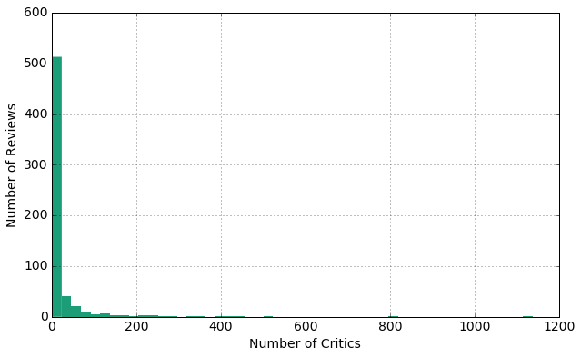

```python
critics.groupby('critic').size().hist(bins=50)
plt.xlabel('Number of Critics')
plt.ylabel('Number of Reviews')
```

#### Here are the 5 critics with the most reviews, along with the publication they write for

```python
top_critics = critics.groupby('critic').size().sort_values(ascending=False).head(5)
top_critics_df = pd.DataFrame({'critic':top_critics.index, 'reviews':top_critics.values})

top_critics_df['publication'] = top_critics_df['critic'].map(lambda x: critics[critics.critic == x]['publication'].unique())

top_critics_df
```

|  | critic | reviews | publication |
| --- | --- | --- | --- |
| 0 | Roger Ebert | 1138 | [Chicago Sun-Times, At the Movies] |
| 1 | James Berardinelli | 807 | [ReelViews] |
| 2 | Janet Maslin | 518 | [New York Times] |
| 3 | Variety Staff | 434 | [Variety] |
| 4 | Jonathan Rosenbaum | 413 | [Chicago Reader] |

#### Of the critics with > 100 reviews, plot the distribution of average "freshness" rating per critic

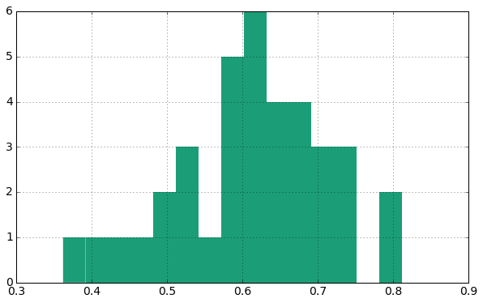

```python
critics['fresh_binary_value'] = critics['fresh'].map({'fresh':1, 'rotten':0})

# find the average ratings for all critics
all_critics_rating = critics.groupby('critic')['fresh_binary_value'].mean()
df = pd.DataFrame(all_critics_rating.values, columns=['avg_rating'], index=all_critics_rating.index)

# find the total number of reviews for each critic
all_critics_reviews = critics.groupby('critic').size()
df = pd.concat([df, pd.DataFrame(all_critics_reviews.values, columns=['no_of_reviews'], index=all_critics_reviews.index)], axis=1)

df[df['no_of_reviews'] > 100].avg_rating.hist(bins=15)
```

```python
critics['year_of_review'] = critics['review_date'].apply(lambda x: x.split('-')[0])
critics.head()
```

|  | critic | fresh | imdb | publication | quote | review_date | rtid | title | fresh_binary_value | year_of_review |
| --- | --- | --- | --- | --- | --- | --- | --- | --- | --- | --- |
| 1 | Derek Adams | fresh | 114709 | Time Out | So ingenious in concept, design and execution ... | 2009-10-04 | 9559 | Toy story | 1.0 | 2009 |
| 2 | Richard Corliss | fresh | 114709 | TIME Magazine | The year's most inventive comedy. | 2008-08-31 | 9559 | Toy story | 1.0 | 2008 |
| 3 | David Ansen | fresh | 114709 | Newsweek | A winning animated feature that has something ... | 2008-08-18 | 9559 | Toy story | 1.0 | 2008 |
| 4 | Leonard Klady | fresh | 114709 | Variety | The film sports a provocative and appealing st... | 2008-06-09 | 9559 | Toy story | 1.0 | 2008 |
| 5 | Jonathan Rosenbaum | fresh | 114709 | Chicago Reader | An entertaining computer-generated, hyperreali... | 2008-03-10 | 9559 | Toy story | 1.0 | 2008 |

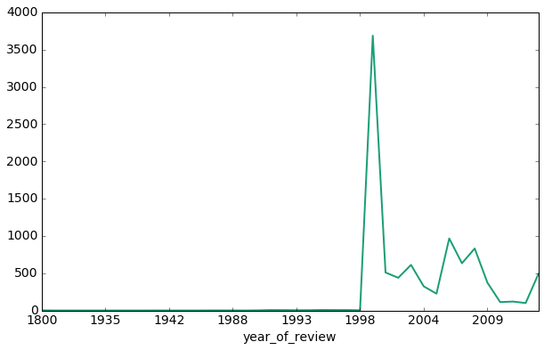

```python
critics[critics.fresh=='fresh'].groupby('year_of_review').size().plot()
```

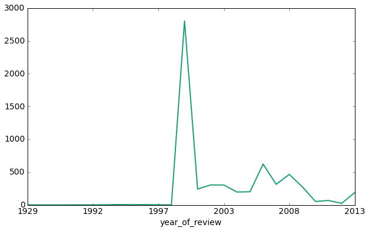

```python
critics[critics.fresh=='rotten'].groupby('year_of_review').size().plot()
```

It appears there is a spike in both 'fresh' and 'rotten' ratings in the year 2000 implying that this dataset contains a large number of movies from 2000. There is at least 1 data point for a movie with 'fresh' rating in the year 1800, and at least one data point for 'rotten' rating in the year 1929. Both these are likely to be junk data. In the following section, I have only looked at movie reviews from the year 2000 onward.

```python
critics = critics[(critics.year_of_review.astype(int) >= 2000)]
```

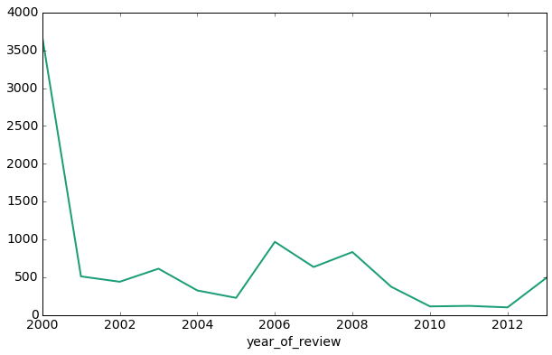

```python
critics[critics.fresh=='fresh'].groupby('year_of_review').size().plot()
```

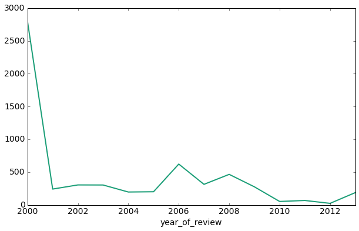

```python
critics[critics.fresh=='rotten'].groupby('year_of_review').size().plot()
```

## Prediction

We can transform text data into numeric vectors using the `CountVectorizer` and `TfidfVectorizer` functions from `sklearn`. After transforming the critic review text, the data can be used in a random forest model for predicting the outcome. Train a random forest model with your transformed data and run cross validation to see what the model fit is like

#### Write a function to transform the review text into data for a random forest model

```python
critics['fresh_binary_value'] = critics['fresh'].map({'fresh':1, 'rotten':0})
critics[~critics.fresh_binary_value.isnull()]['fresh_binary_value'
                                             ].unique()
```

```
array([ 1.,  0.])
```

```python
from sklearn.feature_extraction.text import CountVectorizer, TfidfVectorizer
from sklearn.ensemble import RandomForestClassifier

review_text = critics[~critics.fresh_binary_value.isnull()]['quote'].fillna('')

vectorizer = TfidfVectorizer(max_df=0.85,
                             min_df=2,
                             ngram_range=[1, 2],
                             stop_words='english')
vectorizer.fit(review_text)

# Use `tranform` to generate the sample X word matrix - one column per feature (word or n-grams)
X = vectorizer.transform(review_text).toarray()
```

#### Fit a random forest model on your transformed data

```python
from sklearn.ensemble import RandomForestClassifier

X_df = pd.DataFrame(X, columns = vectorizer.get_feature_names())

y = critics[~critics.fresh_binary_value.isnull()]['fresh_binary_value']

model = RandomForestClassifier(n_estimators = 25, min_samples_leaf=4)
model.fit(X_df, y)
```

```
RandomForestClassifier(bootstrap=True, class_weight=None, criterion='gini',
            max_depth=None, max_features='auto', max_leaf_nodes=None,
            min_samples_leaf=4, min_samples_split=2,
            min_weight_fraction_leaf=0.0, n_estimators=25, n_jobs=1,
            oob_score=False, random_state=None, verbose=0,
            warm_start=False)
```

#### Run cross validation on the model and determine the best parameters

Try modifying the inputs to the `CountVectorizer` or `TfidfVectorizer` models and the `RandomForestClassifier` model

```python
from sklearn.cross_validation import cross_val_score

scores = cross_val_score(model, X, y, scoring='roc_auc')
print('CV AUC {}, Average AUC {}'.format(scores, scores.mean()))
```

```
CV AUC [ 0.76280592  0.75809846  0.76910034], Average AUC 0.763334905742
```

#### Identify the most important features in your model

```python
feature_importances = pd.DataFrame({'Features' : X_df.columns, 'Importance Score': model.feature_importances_})
print feature_importances.sort_values('Importance Score', ascending=False).head(20)
```

```
            Features  Importance Score
6748            film          0.005820
12446          movie          0.004447
1389             bad          0.004427
5908    entertaining          0.004012
5441            dull          0.003642
5155           doesn          0.003445
1719            best          0.003435
9906             isn          0.003200
15311         really          0.003170
7200            flat          0.002983
8072            good          0.002762
19735  unfortunately          0.002683
20841          worst          0.002656
6384           fails          0.002647
10902           like          0.002551
16504         script          0.002490
8276           great          0.002471
14777        problem          0.002469
1963           bland          0.002327
14345           plot          0.002314
```

#### Using Count Vectorizer

```python
vectorizer = CountVectorizer(max_df=0.85,
                             min_df=2,
                             ngram_range=[1, 2],
                             stop_words='english')
vectorizer.fit(review_text)

# Use `tranform` to generate the sample X word matrix - one column per feature (word or n-grams)
X = vectorizer.transform(review_text).toarray()

X_df = pd.DataFrame(X, columns = vectorizer.get_feature_names())

y = critics[~critics.fresh_binary_value.isnull()]['fresh_binary_value']

model = RandomForestClassifier(n_estimators = 25, min_samples_leaf=4)
model.fit(X_df, y)

# Cross Validation score
scores = cross_val_score(model, X, y, scoring='roc_auc')
print('CV AUC {}, Average AUC {}'.format(scores, scores.mean()))

# Identifying the important features
feature_importances = pd.DataFrame({'Features' : X_df.columns, 'Importance Score': model.feature_importances_})
print feature_importances.sort_values('Importance Score', ascending=False).head(20)
```

```
CV AUC [ 0.77724775  0.76522327  0.78784251], Average AUC 0.776771176589
             Features  Importance Score
5908     entertaining          0.012604
1719             best          0.008834
5441             dull          0.008597
1389              bad          0.008259
19735   unfortunately          0.007987
6748             film          0.007618
6384            fails          0.006960
8276            great          0.006608
20841           worst          0.006455
1963            bland          0.006450
13994     performance          0.006448
5931    entertainment          0.006314
15311          really          0.005876
10566            lame          0.005407
11808     masterpiece          0.005214
7200             flat          0.005202
14777         problem          0.005145
20047           video          0.005001
14345            plot          0.004942
4974   disappointment          0.004826
```

For the vectorizer, I tried varying both max_df, min_df, and ngram_range. Increasing ngram_range beyond [1, 2] redices the AUC score, while a min_df of 2 yields the best result. For max_df, I tried increasing to 0.95 which yielded a poorer model.

For the Random Forest model, increasing the n_estimators from 20 to 25 gave better results while further increasing caused the code to take enormous time to run. Increasing the min_samples_leaf from default of 1 to 2 and then to 4 gave progressively better results. Increasing min_samples_split, however, yielded poorer results.

For both CountVectorizer and TfidfVectorizer, binary was set to False.